# Week 4 - Simulation and Profiling

# Week 4 - Simulation & Profiling

## The str Function

str: Completly display the internal structyure of an R object

- A diagnostic function and an alternative to ‘summary’
- It is especially well suited to compactly display the (abbreviated) contents of (spossibly nester) lists.
- Roughly one line per basic object

```r
str(str)
```

```
## function (object, ...)
```

```r
str(lm)
```

```
## function (formula, data, subset, weights, na.action, method = "qr", model = TRUE,
##     x = FALSE, y = FALSE, qr = TRUE, singular.ok = TRUE, contrasts = NULL,
##     offset, ...)
```

```r
x <- rnorm(100, 2, 4)
x
```

```
##   [1]  9.658901156  0.530519183  1.852429815  2.688785743 -4.631976058
##   [6]  4.907150327 -0.005656464 -6.607484916 -0.474951039  7.057891362
##  [11]  4.509410979  2.466865641  1.217885954  1.934699193  5.739502875
##  [16]  0.695915584 -4.495608597  1.522169612  3.941734655  2.034105409
##  [21]  5.855154842  1.696217950  6.072539765  5.916919471  9.756397689
##  [26]  1.239217414  1.604175091  2.969551216 -0.156688200 -0.278828343
##  [31]  0.434967718  0.301138025  7.916497771 -1.809141212  1.848602071
##  [36]  0.410521091 -5.280713979  3.377254951  2.790715449  6.699500637
##  [41] -2.742826367  0.955930424 10.493120500 -0.525115721  2.534990892
##  [46] -1.354162036 -1.083018311  4.525166640  0.725203888 -2.278169374
##  [51]  0.982787655  3.988147869 -1.079707072  1.034045999  5.562964264
##  [56] -0.970792127 -8.899817255  0.753102110  4.678856876  2.781308509
##  [61]  3.481770275  3.666555356 -4.698764240  1.403923084  3.102406952
##  [66]  2.636064736  0.381897260  2.628716540  3.278717880 -1.485863647
##  [71] -3.118492987 -1.019247159  0.921531511 -1.951582101  3.176581559
##  [76]  4.115219708  2.624502820  6.726687313  0.847260095 -3.217468058
##  [81]  1.486331593 -3.279758745 -1.363440973  0.616208838  5.738760292
##  [86] -0.662005018  4.321105130  0.474819167  3.837484360  0.956501290
##  [91]  1.127229754  0.591994364 -2.492332220  5.127884753 -2.284746194
##  [96]  0.700251083  0.411231567  6.480733801 -0.889101089  2.338634171
```

```r
summary(x)
```

```
##    Min. 1st Qu.  Median    Mean 3rd Qu.    Max.
## -8.8998 -0.4875  1.2286  1.5273  3.5280 10.4931
```

```r
str(x)
```

```
##  num [1:100] 9.659 0.531 1.852 2.689 -4.632 ...
```

x is a numeric vector, has 100 elements in it, and gives first 5 elements.

```r
f <- gl(40,10)
str(f)
```

```
##  Factor w/ 40 levels "1","2","3","4",..: 1 1 1 1 1 1 1 1 1 1 ...
```

```r
summary(f)
```

```
##  1  2  3  4  5  6  7  8  9 10 11 12 13 14 15 16 17 18 19 20 21 22 23 24 25 26
## 10 10 10 10 10 10 10 10 10 10 10 10 10 10 10 10 10 10 10 10 10 10 10 10 10 10
## 27 28 29 30 31 32 33 34 35 36 37 38 39 40
## 10 10 10 10 10 10 10 10 10 10 10 10 10 10
```

```r
library(datasets)
head(airquality)
```

|  | Ozone | Solar.R | Wind | Temp | Month | Day |
| --- | --- | --- | --- | --- | --- | --- |
| 1 | 41 | 190 | 7.4 | 67 | 5 | 1 |
| 2 | 36 | 118 | 8.0 | 72 | 5 | 2 |
| 3 | 12 | 149 | 12.6 | 74 | 5 | 3 |
| 4 | 18 | 313 | 11.5 | 62 | 5 | 4 |
| 5 | NA | NA | 14.3 | 56 | 5 | 5 |
| 6 | 28 | NA | 14.9 | 66 | 5 | 6 |

```r
str(airquality)
```

```
## 'data.frame':    153 obs. of  6 variables:
##  $ Ozone  : int  41 36 12 18 NA 28 23 19 8 NA ...
##  $ Solar.R: int  190 118 149 313 NA NA 299 99 19 194 ...
##  $ Wind   : num  7.4 8 12.6 11.5 14.3 14.9 8.6 13.8 20.1 8.6 ...
##  $ Temp   : int  67 72 74 62 56 66 65 59 61 69 ...
##  $ Month  : int  5 5 5 5 5 5 5 5 5 5 ...
##  $ Day    : int  1 2 3 4 5 6 7 8 9 10 ...
```

```r
m <- matrix(rnorm(100,10,10))
str(m)
```

```
##  num [1:100, 1] 21.26 1.35 24.47 19.91 8.44 ...
```

```r
m[,1]
```

```
##   [1]  21.25676553   1.34825324  24.46832537  19.90912791   8.43982272
##   [6]  19.61507470   3.02360794  18.31703496   9.15724574  18.84220119
##  [11]  13.14077554 -10.18820379   6.56996873 -10.41861765  11.02944020
##  [16]  18.05899834  19.86589696  20.68277213  -9.85813185   7.65895566
##  [21]  16.11798870   0.49967883   8.15736769   4.95379098   7.90913224
##  [26]   8.07822779   5.12763111   1.62735784   4.48333392   3.87119620
##  [31]  -1.09323226  11.36225984  -3.78743752  41.47916899 -21.07899473
##  [36]  12.43369277   6.75064634   2.60474242   2.55990566   5.46746426
##  [41]  15.53287597  14.26670797  17.84440515  -0.75097351  21.20749448
##  [46]   4.69370600  -5.03274627   0.21479299  19.47260229  -7.68185727
##  [51]   1.73856655  11.40316398   5.97074066   7.97717847   9.71218678
##  [56]  -4.61911299   1.06581630  19.02699368  28.40615362  15.60764445
##  [61]   7.18846090  13.14597648  -2.41067607  -3.29755765  11.69273324
##  [66]  18.91034857   0.66564385  18.96502904  16.98580593   2.49061921
##  [71]   2.69923338  -1.43497674   7.27985664   5.82672678   2.89177885
##  [76]  18.05312683  23.35068367  16.69614387   0.01833793   6.73073790
##  [81]  32.70510426  18.31324393  22.17685163   4.40117595  15.12653552
##  [86]  11.34105507  19.34484359  14.12881769 -12.06444672   5.98759076
##  [91]   7.89301585  20.42128026  24.99365992   1.46984354  19.04222606
##  [96]  10.12881064  -0.48146847  10.40919982   7.89801015  28.51325328
```

```r
s <- split(airquality, airquality$Month)
s
```

```
## $`5`
##    Ozone Solar.R Wind Temp Month Day
## 1     41     190  7.4   67     5   1
## 2     36     118  8.0   72     5   2
## 3     12     149 12.6   74     5   3
## 4     18     313 11.5   62     5   4
## 5     NA      NA 14.3   56     5   5
## 6     28      NA 14.9   66     5   6
## 7     23     299  8.6   65     5   7
## 8     19      99 13.8   59     5   8
## 9      8      19 20.1   61     5   9
## 10    NA     194  8.6   69     5  10
## 11     7      NA  6.9   74     5  11
## 12    16     256  9.7   69     5  12
## 13    11     290  9.2   66     5  13
```

[output cut: 152 more lines]

```r
str(s)
```

```
## List of 5
##  $ 5:'data.frame':   31 obs. of  6 variables:
##   ..$ Ozone  : int [1:31] 41 36 12 18 NA 28 23 19 8 NA ...
##   ..$ Solar.R: int [1:31] 190 118 149 313 NA NA 299 99 19 194 ...
##   ..$ Wind   : num [1:31] 7.4 8 12.6 11.5 14.3 14.9 8.6 13.8 20.1 8.6 ...
##   ..$ Temp   : int [1:31] 67 72 74 62 56 66 65 59 61 69 ...
##   ..$ Month  : int [1:31] 5 5 5 5 5 5 5 5 5 5 ...
##   ..$ Day    : int [1:31] 1 2 3 4 5 6 7 8 9 10 ...
##  $ 6:'data.frame':   30 obs. of  6 variables:
##   ..$ Ozone  : int [1:30] NA NA NA NA NA NA 29 NA 71 39 ...
##   ..$ Solar.R: int [1:30] 286 287 242 186 220 264 127 273 291 323 ...
##   ..$ Wind   : num [1:30] 8.6 9.7 16.1 9.2 8.6 14.3 9.7 6.9 13.8 11.5 ...
##   ..$ Temp   : int [1:30] 78 74 67 84 85 79 82 87 90 87 ...
##   ..$ Month  : int [1:30] 6 6 6 6 6 6 6 6 6 6 ...
##   ..$ Day    : int [1:30] 1 2 3 4 5 6 7 8 9 10 ...
##  $ 7:'data.frame':   31 obs. of  6 variables:
##   ..$ Ozone  : int [1:31] 135 49 32 NA 64 40 77 97 97 85 ...
##   ..$ Solar.R: int [1:31] 269 248 236 101 175 314 276 267 272 175 ...
##   ..$ Wind   : num [1:31] 4.1 9.2 9.2 10.9 4.6 10.9 5.1 6.3 5.7 7.4 ...
##   ..$ Temp   : int [1:31] 84 85 81 84 83 83 88 92 92 89 ...
##   ..$ Month  : int [1:31] 7 7 7 7 7 7 7 7 7 7 ...
##   ..$ Day    : int [1:31] 1 2 3 4 5 6 7 8 9 10 ...
##  $ 8:'data.frame':   31 obs. of  6 variables:
##   ..$ Ozone  : int [1:31] 39 9 16 78 35 66 122 89 110 NA ...
##   ..$ Solar.R: int [1:31] 83 24 77 NA NA NA 255 229 207 222 ...
##   ..$ Wind   : num [1:31] 6.9 13.8 7.4 6.9 7.4 4.6 4 10.3 8 8.6 ...
##   ..$ Temp   : int [1:31] 81 81 82 86 85 87 89 90 90 92 ...
##   ..$ Month  : int [1:31] 8 8 8 8 8 8 8 8 8 8 ...
##   ..$ Day    : int [1:31] 1 2 3 4 5 6 7 8 9 10 ...
##  $ 9:'data.frame':   30 obs. of  6 variables:
##   ..$ Ozone  : int [1:30] 96 78 73 91 47 32 20 23 21 24 ...
##   ..$ Solar.R: int [1:30] 167 197 183 189 95 92 252 220 230 259 ...
##   ..$ Wind   : num [1:30] 6.9 5.1 2.8 4.6 7.4 15.5 10.9 10.3 10.9 9.7 ...
##   ..$ Temp   : int [1:30] 91 92 93 93 87 84 80 78 75 73 ...
##   ..$ Month  : int [1:30] 9 9 9 9 9 9 9 9 9 9 ...
##   ..$ Day    : int [1:30] 1 2 3 4 5 6 7 8 9 10 ...
```

## Simulation - Generating Random Numbers

Functions for probability distributions in R

· rnorm: generate random Normal variates with a given mean and standard deviation · dnorm: evaluate the Normal probability density (with a given mean/SD) at a point (or vector of points) · pnorm: evaluate the cumulative distribution function for a Normal distribution · rpois: generate random Poisson variates with a given rate

Probability distribution functions usually have four functions associated with them. The functions are prefixed with a · d for density · r for random number generation · p for cumulative distribution · q for quantile function

Working with the Normal distributions requires using these four functions

```
dnorm(x, mean = 0, sd = 1, log = FALSE)
pnorm(q, mean = 0, sd = 1, lower.tail = TRUE, log.p = FALSE)
qnorm(p, mean = 0, sd = 1, lower.tail = TRUE, log.p = FALSE)
rnorm(n, mean = 0, sd = 1)
```

If Φ is the cumulative distribution function for a standard Normal distribution, then pnorm(q) = Φ(q) and qnorm(p) = Φ−1 (p).

```r
x <- rnorm(10)
x
```

```
##  [1]  0.4345839 -0.6626889 -0.6038388  1.8818577 -1.9326019 -0.6964707
##  [7]  0.7330582 -0.8444502  1.1545039 -0.2527161
```

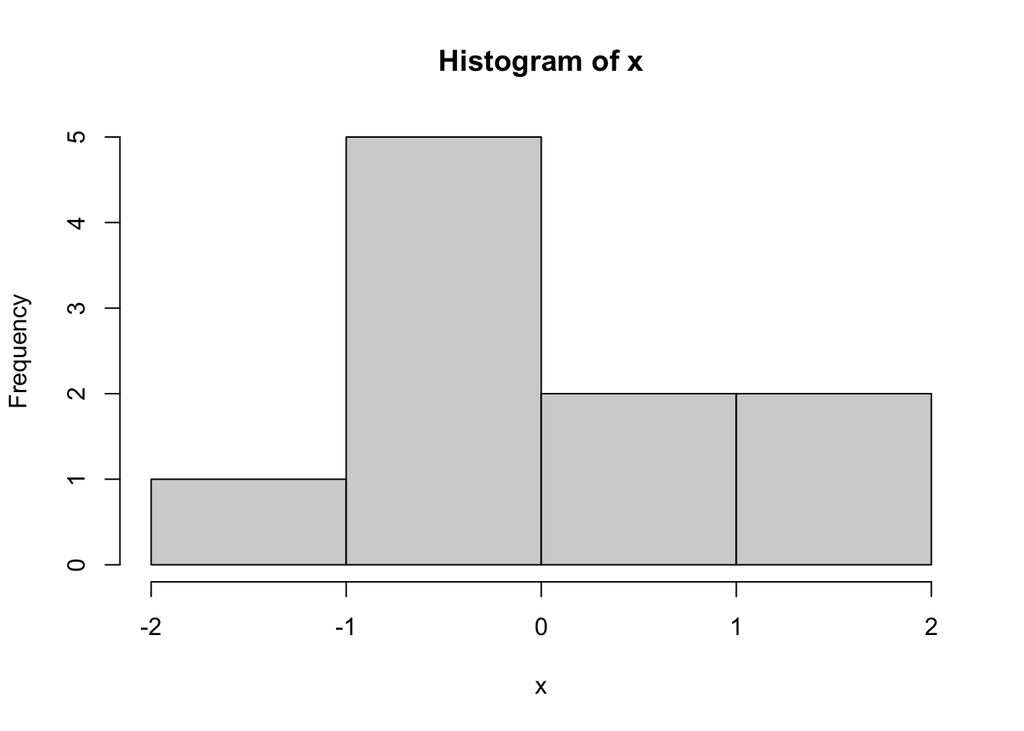

```r
hist(x)
```

```r
x <- rnorm(10,20,2)
x
```

```
##  [1] 16.00673 19.85813 20.24455 19.82275 21.26456 19.75335 24.64971 21.62338
##  [9] 21.97204 22.31175
```

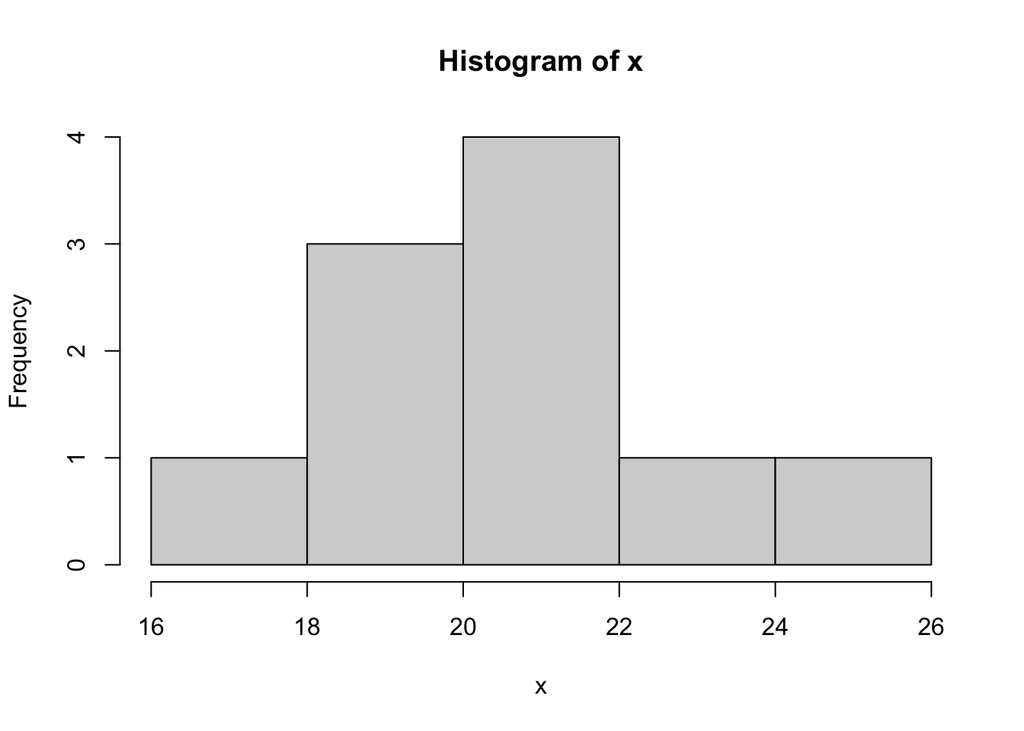

```r
hist(x)
```

```r
summary(x)
```

```
##    Min. 1st Qu.  Median    Mean 3rd Qu.    Max.
##   16.01   19.83   20.75   20.75   21.88   24.65
```

Setting the random number seed with set.seed ensures reproducibility

```r
set.seed(1)
rnorm(5)
```

```
## [1] -0.6264538  0.1836433 -0.8356286  1.5952808  0.3295078
```

```r
rnorm(5)
```

```
## [1] -0.8204684  0.4874291  0.7383247  0.5757814 -0.3053884
```

```r
set.seed(1)
rnorm(5)
```

```
## [1] -0.6264538  0.1836433 -0.8356286  1.5952808  0.3295078
```

Always set the random number seed when conducting a simulation!

Generating Poisson data

```r
rpois(10, 1)
```

```
##  [1] 0 0 1 1 2 1 1 4 1 2
```

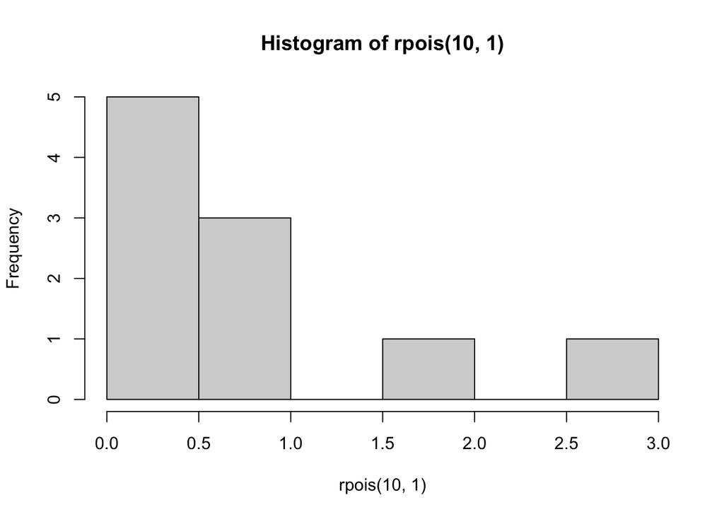

```r
hist(rpois(10, 1))
```

```r
rpois(10, 20)
```

```
##  [1] 19 19 24 23 22 24 23 20 11 22
```

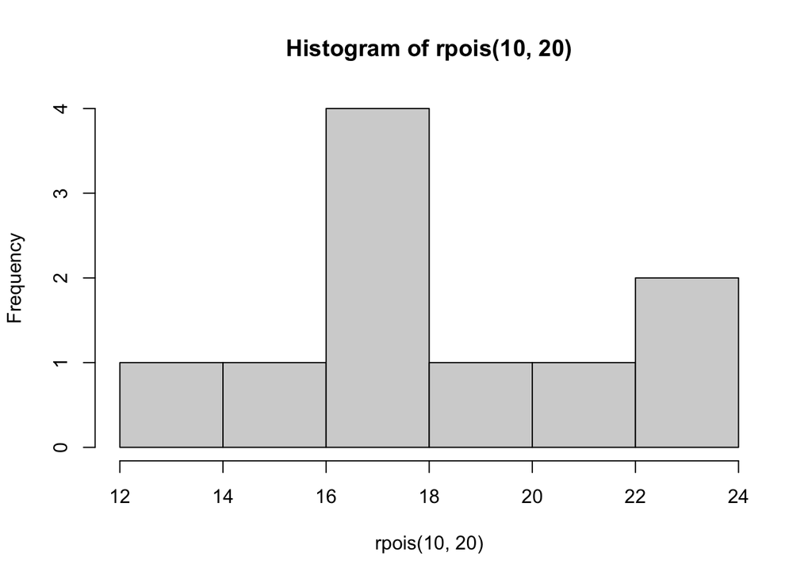

```r
hist(rpois(10, 20))
```

```r
ppois(2, 2) ## Cumulative distribution
```

```
## [1] 0.6766764
```

Pr(x <= 2)

```r
ppois(6, 2)
```

```
## [1] 0.9954662
```

Pr(x <= 6)

```r
ppois(4, 2)
```

```
## [1] 0.947347
```

Pr(x <= 4)